# HW02: Practice with logistic regression and decision tree

[Owen Jennings omjennings]

## Hello Students:

- Start by downloading HW02.ipynb from this folder. Then develop it into your solution.
- Write code where you see "... your code here ..." below. (You are welcome to use more than one cell.)
- If you have questions, please ask them in class, office hours, or piazza. Our TA and I are very happy to help with the programming (provided you start early enough, and provided we are not helping so much that we undermine your learning).
- When you are done, run these Notebook commands:
  - Shift-L (once, so that line numbers are visible)
  - Kernel > Restart and Run All (run all cells from scratch)
  - Esc S (save)
  - File > Download as > HTML
- Turn in:
  - HW02.ipynb to Canvas's HW02.ipynb assignment
  - HW02.html to Canvas's HW02.html assignment
  - As a check, download your files from Canvas to a new 'junk' folder. Try 'Kernel > Restart and Run All' on the '.ipynb' file to make sure it works. Glance through the '.html' file.
- Turn in partial solutions to Canvas before the deadline. e.g. Turn in part 1, then parts 1 and 2, then your whole solution. That way we can award partial credit even if you miss the deadline. We will grade your last submission before the deadline.

```python
import pandas as pd
import numpy as np
import matplotlib.pyplot as plt
from sklearn import linear_model

from sklearn.tree import DecisionTreeClassifier
from sklearn import tree # for tree.plot_tree()
from sklearn.tree import export_text # for export_text()
```

# 1. Logistic regression

# 1a. Make a logistic regression model

- Read http://www.stat.wisc.edu/~jgillett/451/data/iris.csv into a DataFrame.
- Make a second data frame that excludes the 'setosa' rows (leaving the 'virginica' and 'versicolor' rows) and includes only the Petal.Length and Species columns.
- Train the model using $X=$ petal length and $y=$ whether the Species is 'virginica'. (I used "y = (df['Species'] == 'virginica').to_numpy().astype(int)", which sets y to zeros and ones.)
- Report its accuracy on the training data.
- Report the estimated P(Species=virginica | Petal.Length=5).
- Report the predicited Species for Petal.Length=5. (model.predict(Petal.Length == 5))
- Make a plot showing:
  - the data points
  - the estimated logistic curve
  - and what I have called the "sample proportion" of y == 1 at each unique Petal.Length value
  - a legend and title and other labels necessary to make the plot easy to read

```python
df = pd.read_csv("http://www.stat.wisc.edu/~jgillett/451/data/iris.csv")
df

df2 = df[df['Species'] != 'setosa']
df2 = df2[['Petal.Length', 'Species']]

y = (df['Species'] == 'virginica').to_numpy().astype(int)

X= df['Petal.Length'].to_numpy()
X = X.reshape(-1,1)

model = linear_model.LogisticRegression(C=1000)

model.fit(X, y)

b = model.intercept_
w = model.coef_[0]
estimate = model.predict_proba([[5]])[:,1]
score = model.score(X,y)
predicted = model.predict([[5]])
print(f' The accuracy on the training data is {score}.')
print(f' The Estimated probability of virginica given Petal Length = 5 is {estimate}.')
print(f' The Predicted species of Petal Length = 5 is {predicted} which is Virginica.')
```

```
 The accuracy on the training data is 0.9533333333333334.
 The Estimated probability of virginica given Petal Length = 5 is [0.77253918].
 The Predicted species of Petal Length = 5 is [1] which is Virginica.
```

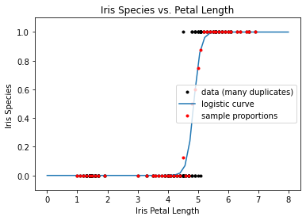

```python
low =  0
high = 8
plt.plot(X, y, '.', color='black', label='data (many duplicates)')
#plt.xlim(low, high)
margin = 0.1
plt.ylim(0 - margin, 1 + margin)
plt.title('Iris Species vs. Petal Length')
plt.xlabel('Iris Petal Length')
plt.ylabel('Iris Species ')


# plot curve
xplot = np.linspace(start=low, stop=high)
yplot = 1 / (1 + np.exp(-(w * xplot + b)))

plt.plot(xplot, yplot, label='logistic curve')

# find and plot sample proportions
x_values, x_counts = np.unique(X, return_counts=True)
n_x_values = x_values.shape[0]
success_proportion_per_x_value = np.zeros(n_x_values)
for i in np.arange(n_x_values):
    success_proportion_per_x_value[i] = np.sum(y[X[:, 0] == x_values[i]]) / x_counts[i]

probs = model.predict_proba(X)[:, 0] # column 0 is P(y_i = 1); column 1 is P(y_i = 0)
plt.plot(x_values, success_proportion_per_x_value, '.', color='red',
         label='sample proportions')

plt.legend(loc='center right')
plt.show(block=False)
```

## 1b. Do some work with logistic regression by hand.

Consider the logistic regression model, $P(y _i = 1) = \frac{1}{1 + e^{-(\mathbf{w x} + b)}}\,.$

Logistic regression is named after the log-odds of success, $\ln \frac{p}{1 - p}$, where $p = P(y_i = 1)$. Show that this log-odds equals $\mathbf{w x} + b$. (That is, start with $\ln \frac{p}{1 - p}$ and connect it in a series of equalities to $\mathbf{w x} + b$.)

$\begin{align*} % In this Latex context, "&" separates columns and "\\" ends a line. \ln \frac{p}{1 - p} & = \ln(p) {-} ln(1-p) \\ & = \ln \frac{1}{1+e^{-(wx+b)}} {-} \ln(1 - \frac{1}{1+e^{-(wx+b)}}) \\ & = \ln(1) {-} \ln(1+e^{-(wx+b)}) {-} \ln(\frac{1+e^{-(wx+b)}-1}{1+e^{-(wx+b)}}) \\ & = -(\ln(e^{-(wx+b)}) \\ & = \mathbf{w x} + b\\ \end{align*} $

### 1c. Do some more work with logistic regression by hand.

I ran some Python/scikit-learn code to make the model pictured here:

[figure not shown]

From the image and without the help of running code, match each code line from the top list with its output from the bottom list.

1. `model.intercept_`
2. `model.coef_`
3. `model.predict(X)`
4. `model.predict_proba(X)[:, 1]`

A. `array([0, 0, 0, 1])`, B. `array([0.003, 0.5, 0.5, 0.997])`, C. `array([5.832])`, D. `array([0.])`

"1: D, 2: C, 3: A, 4: B"

# 2. Decision tree

## 2a. Make a decision tree model on a Titanic data set.

Read the data from http://www.stat.wisc.edu/~jgillett/451/data/kaggle_titanic_train.csv.

These data are described at https://www.kaggle.com/competitions/titanic/data (click on the small down-arrow to see the "Data Dictionary"), which is where they are from.

- Retain only the Survived, Pclass, Sex, and Age columns.
- Display the first seven rows (passengers). Notice that the Age column includes NaN, indicating a missing value.
- Drop rows with missing data via `df.dropna()`. Display your data frame's shape before and after dropping rows. (It should be (714, 4) after dropping rows.)
- Add a column called 'Female' that indicates whether a passenger is Female. You can make this column via `df.Sex == 'female'`. This gives bool values True and False, which are interpreted as 1 and 0 when used in an arithmetic context.
- Train a decision tree with `max_depth=None` to decided whether a passenger `Survived` from the other three columns. Report its accuracy (with 3 decimal places) on training data along with the tree's depth (which is available in `clf.tree_.max_depth`).
- Train another tree with `max_depth=2`. Report its accuracy (with 3 decimal places). Use `tree.plot_tree()` to display it, including feature_names to make the tree easy to read.

```python
df = pd.read_csv("http://www.stat.wisc.edu/~jgillett/451/data/kaggle_titanic_train.csv")
df = df.drop(columns = ['Name', 'PassengerId', 'SibSp', 'Parch', 'Ticket', 'Fare', 'Cabin', 'Embarked'])
df.head(7)
df['Female'] = (df.Sex == 'female')
df2 = df.dropna()
df2
```

|  | Survived | Pclass | Sex | Age | Female |
| --- | --- | --- | --- | --- | --- |
| 0 | 0 | 3 | male | 22.0 | False |
| 1 | 1 | 1 | female | 38.0 | True |
| 2 | 1 | 3 | female | 26.0 | True |
| 3 | 1 | 1 | female | 35.0 | True |
| 4 | 0 | 3 | male | 35.0 | False |
| ... | ... | ... | ... | ... | ... |
| 885 | 0 | 3 | female | 39.0 | True |
| 886 | 0 | 2 | male | 27.0 | False |
| 887 | 1 | 1 | female | 19.0 | True |
| 889 | 1 | 1 | male | 26.0 | False |
| 890 | 0 | 3 | male | 32.0 | False |

714 rows × 5 columns

```python
feature_names = ['Age', 'Pclass', 'Female']
X = df2[feature_names].to_numpy()
y = df2['Survived'].to_numpy()
clf = DecisionTreeClassifier(criterion='entropy', max_depth=None, random_state=0)
clf.fit(X, y)
plt.rcParams["figure.figsize"] = (8, 7) # (width, height) https://matplotlib.org/stable/api/figure_api.html
print(f'Accuracy on training data is clf.score(X, y)={round(clf.score(X, y),3)} and the max depth is {clf.tree_.max_depth}.')
```

```
Accuracy on training data is clf.score(X, y)=0.896 and the max depth is 15.
```

```
Accuracy on training data is clf.score(X, y)=0.791.
```

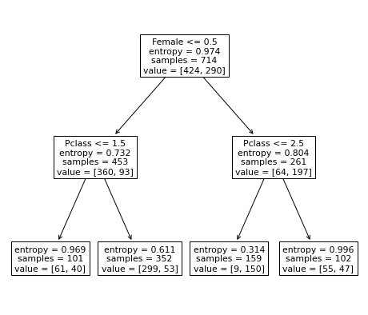

```python
feature_names = ['Age', 'Pclass', 'Female']
X = df2[feature_names].to_numpy()
y = df2['Survived'].to_numpy()
clf = DecisionTreeClassifier(criterion='entropy', max_depth=2, random_state=0)
clf.fit(X, y)
plt.rcParams["figure.figsize"] = (8, 7)
tree.plot_tree(clf, feature_names=feature_names)
print(f'Accuracy on training data is clf.score(X, y)={round(clf.score(X, y),3)}.')
```

## 2b. Which features are used in the (max_depth=2) decision-making? Answer in a markdown cell.

In the max_depth = 2 decision making, the features used are Female and Pclass.

## 2c. What proportion of females survived? What proportion of males survived?

Answer in two sentences via print(), with each proportion rounded to three decimal places.

Hint: There are many ways to do this. One quick way is to find the average of the `Female` column for each subset.

```python
f_survived = df2[(df2["Female"] == True)].mean()[0]
m_survived = df2[(df2["Female"] == False)].mean()[0]
print(f' The proportion of females survived is {f_survived:.3}.')
print(f' The proportion of males survived is {m_survived:.3}.')
```

```
 The proportion of females survived is 0.755.
 The proportion of males survived is 0.205.
```

## 2d. Do some decision tree calculations by hand.

Consider a decision tree node containing the following set of examples $S = \{(\mathbf{x}, y)\}$ where $\mathbf{x} = (x_1, x_2)$:

((4, 9), 1)

((2, 6), 0)

((5, 7), 0)

((3, 8), 1)

Find the entropy of $S$.

p1 = 2/4 = .5

p0 = 2/4 = .5

log2(p1) = -1 log2(p0) = -1

H(S) = -(.5*-1 ) - (.5* -1 ) = 1

The entropy is 1 because it is perfectly mixed with two 0's and two 1's in the y-value of the pairs.

## 2e. Do some more decision tree calculations by hand.

Find a (feature, threshold) pair that yields the best split for this node.

For attribute X_2, the threshold of 7.5 will split the nodes.

prob_0 = 2/2 = 1 = -(1* log2(1)) = 0

prob_1 = 2/2 = 1 = -1*log2(1) = 0

(2/4 *0) + (2/4* 0) = 0